# Case Study 2: Predicting Attrition and Salary

Katherine Lockard

8/6/2021

[YouTube Presentation](https://youtu.be/PtFPW_gCeH8)

## Introduction

In this case study, we will examine employee characteristics at Frito Lay. This dataset contained 870 observations and 36 different variables. Later, we will explore predictors for employee attrition in order to create a model that will predict attrition and we will explore variables related to Monthly Income in order to create a linear regression model that estimates monthly income.

First, make sure required libraries are installed. Some important ones we used are: e1071 for Naive Bayes, ggplot2 for visualization, olsrr for variable selection, caret & class were used for kNN, and visdat to visualize missing values.

```r
#load Packages
library(ggplot2)
library(dplyr)
library(visdat)
library(tidyverse)
library(tinytex)
library(caret)
library(e1071)
library(class)
library(olsrr)
library(GGally)
library(readxl)
#Read in data files
DDS_data <- read.csv(file = "/Users/katherinelockard/Documents/SMU/Doing Data Science/Case Study 2/CaseStudy2-data.csv")
DDS_Test <- read.csv(file ="/Users/katherinelockard/Documents/SMU/Doing Data Science/Case Study 2/CaseStudy2Test.csv")
```

Next, visualize the missing data. All data is accounted for!

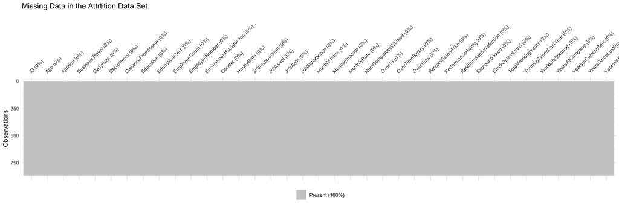

```r
#No missing data!! Woohoo
vis_miss(DDS_data) + ggtitle("Missing Data in the Attrtition Data Set")
```

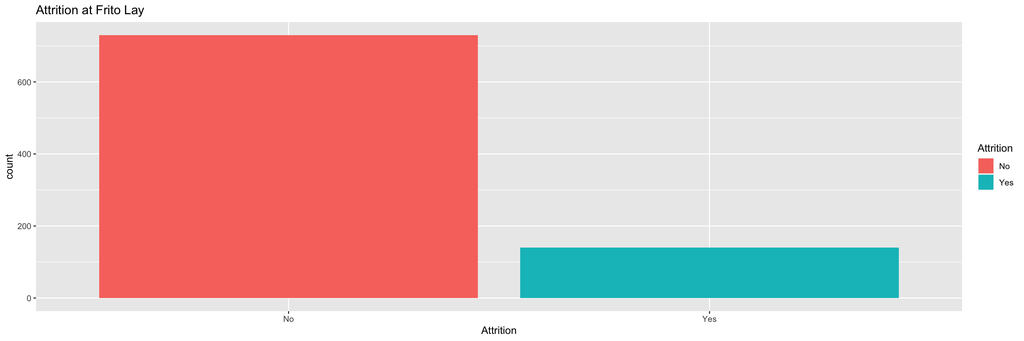

```r
#Visualize relationships between attrition and each variable
ggplot(data = DDS_data) + geom_bar(aes(x = Attrition, fill = Attrition)) + ggtitle("Attrition at Frito Lay")
```

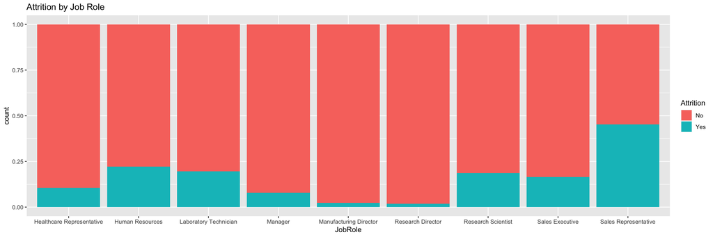

```r
ggplot(data = DDS_data) + geom_bar(aes(x = JobRole, fill = Attrition), position = "fill") + ggtitle("Attrition by Job Role")
```

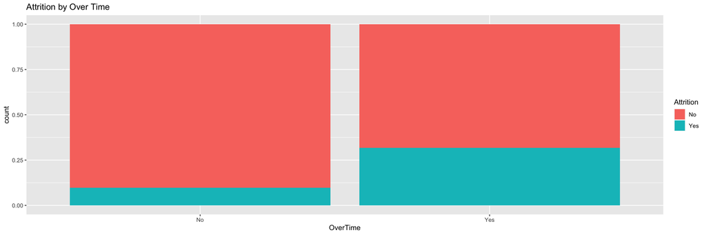

```r
ggplot(data = DDS_data) + geom_bar(aes(x = OverTime, fill = Attrition), position = "fill") + ggtitle("Attrition by Over Time")
```

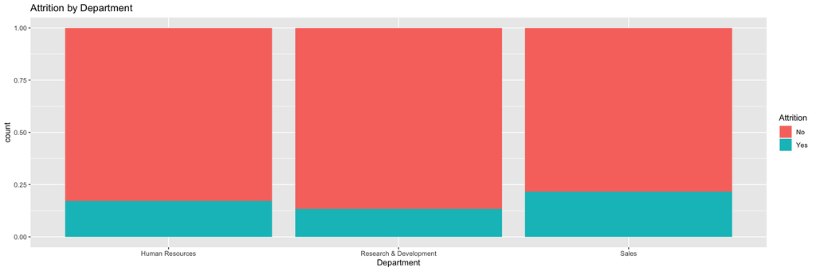

```r
ggplot(data = DDS_data) + geom_bar(aes(x = Department, fill = Attrition), position = "fill") + ggtitle("Attrition by Department")
```

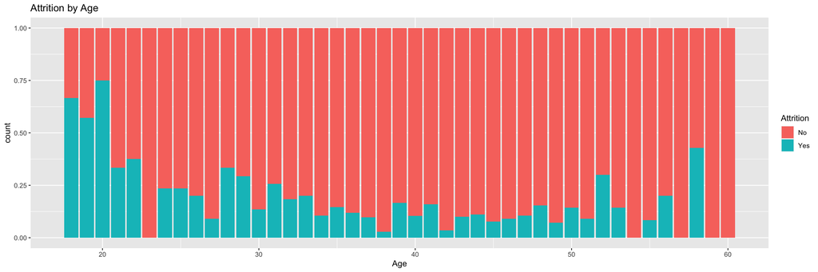

```r
ggplot(data = DDS_data) + geom_bar(aes(x = Age, fill = Attrition), position = "fill") + ggtitle("Attrition by Age")
```

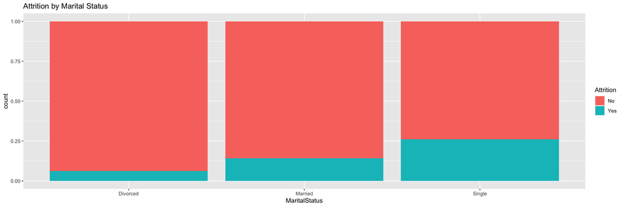

```r
ggplot(data = DDS_data) + geom_bar(aes(x = MaritalStatus, fill = Attrition), position = "fill") + ggtitle("Attrition by Marital Status")
```

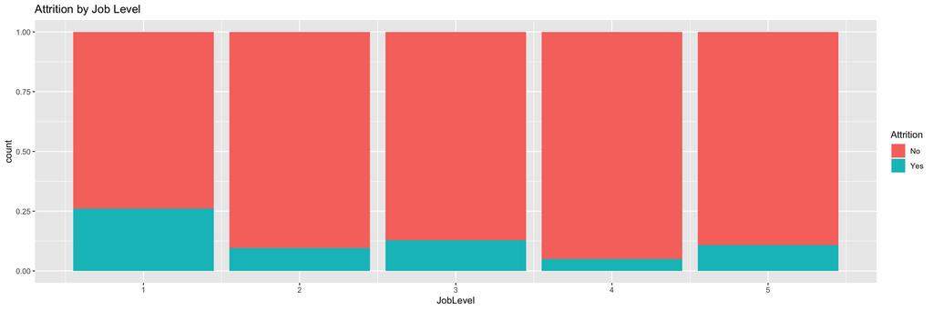

```r
ggplot(data = DDS_data) + geom_bar(aes(x = JobLevel, fill = Attrition), position = "fill") + ggtitle("Attrition by Job Level")
```

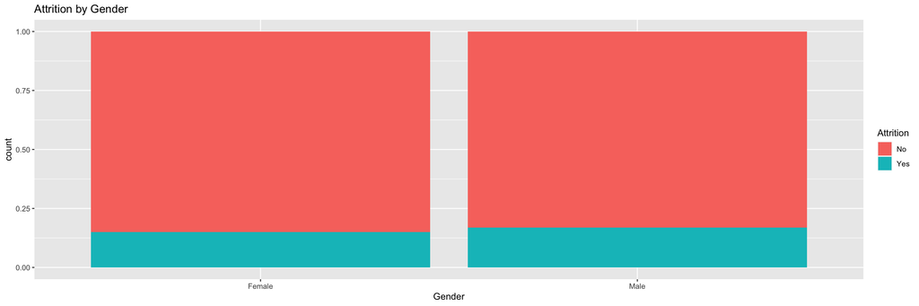

```r
ggplot(data = DDS_data) + geom_bar(aes(x = Gender, fill = Attrition), position = "fill") + ggtitle("Attrition by Gender")
```

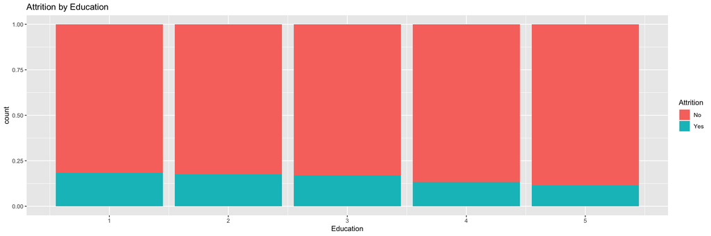

```r
ggplot(data = DDS_data) + geom_bar(aes(x = Education, fill = Attrition), position = "fill") + ggtitle("Attrition by Education")
```

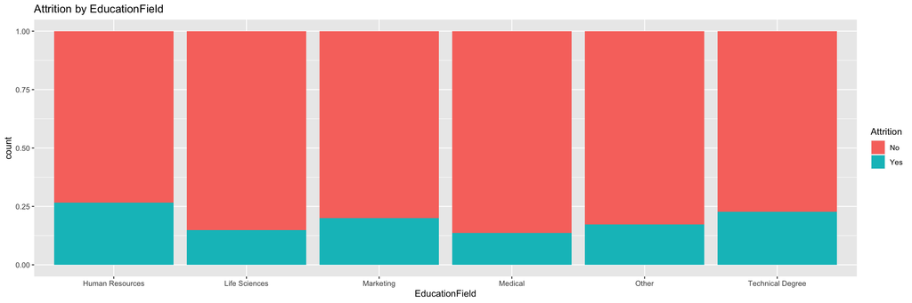

```r
ggplot(data = DDS_data) + geom_bar(aes(x = EducationField, fill = Attrition), position = "fill") + ggtitle("Attrition by EducationField")
```

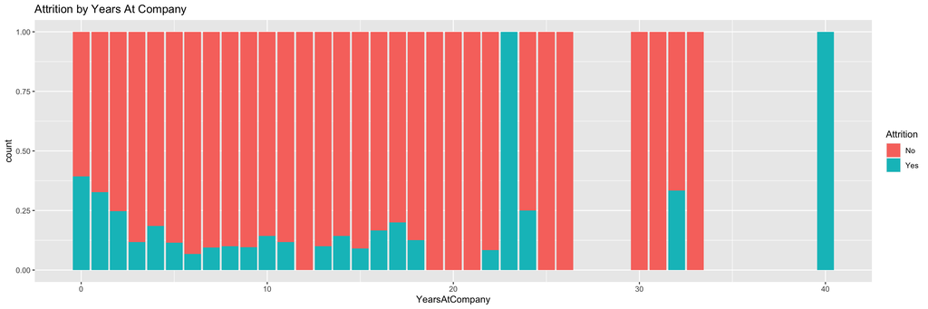

```r
ggplot(data = DDS_data) + geom_bar(aes(x = YearsAtCompany, fill = Attrition), position = "fill") + ggtitle("Attrition by Years At Company")
```

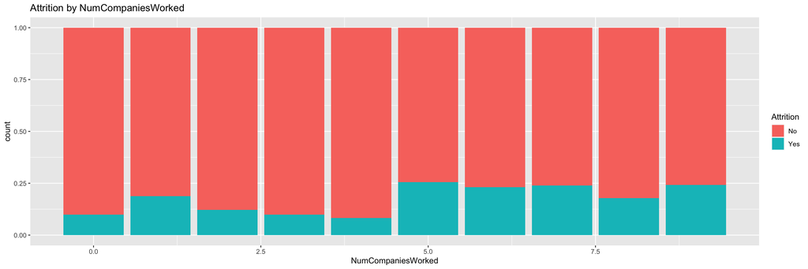

```r
ggplot(data = DDS_data) + geom_bar(aes(x = NumCompaniesWorked, fill = Attrition), position = "fill") + ggtitle("Attrition by NumCompaniesWorked")
```